# CollegeData

```r
collegedata = read.csv("MERGED2019_20_PP.csv")
```

## Plots

```r
library(dplyr)
library(knitr)
library(skimr)
highadmithighendow = collegedata %>% filter(ADM_RATE > 0.3) %>% filter(ENDOWBEGIN > 10^5)
#which(collegedata["ADM_RATE"] <= 0.2)
```

[figure not shown]

```r
#install.packages("skimr")
```

## Summary Stats

**75% of institutions have a 56%+ acceptance rate**:

```r
admrates = sapply(collegedata["ADM_RATE"],as.numeric)
admrates<-admrates[!is.na(admrates)]
#admrates
skim(admrates) %>% tibble() %>% kable()
```

| skim_type | skim_variable | n_missing | complete_rate | numeric.mean | numeric.sd | numeric.p0 | numeric.p25 | numeric.p50 | numeric.p75 | numeric.p100 | numeric.hist |
| --- | --- | --- | --- | --- | --- | --- | --- | --- | --- | --- | --- |
| numeric | data | 0 | 1 | 0.6896551 | 0.2209901 | 0 | 0.562725 | 0.7267 | 0.85255 | 1 | ▁▂▅▇▇ |

```r
#(collegedata %>% filter(!is.na(ADM_RATE)))["ADM_RATE"]
#summary(collegedata$ADM_RATE)
```

**The median endowment is around $18 million**:

```r
endow = sapply(collegedata["ENDOWBEGIN"],as.numeric)
endow<-endow[!is.na(endow)]
#admrates
skim(endow) %>% tibble() %>% kable()
```

| skim_type | skim_variable | n_missing | complete_rate | numeric.mean | numeric.sd | numeric.p0 | numeric.p25 | numeric.p50 | numeric.p75 | numeric.p100 | numeric.hist |
| --- | --- | --- | --- | --- | --- | --- | --- | --- | --- | --- | --- |
| numeric | data | 0 | 1 | 223384760 | 1430741608 | 0 | 4069181 | 18459978 | 72362050 | 39233736000 | ▇▁▁▁▁ |

```r
print(length(endow))
```

```
## [1] 2726
```

**The median number of undergrads is just 761, and the twenty-fifth percentile is just 180 undergrads!**

```r
undergrads = sapply(collegedata["UG12MN"],as.numeric)
undergrads<-undergrads[!is.na(undergrads)]
#admrates
skim(undergrads) %>% tibble() %>% kable()
```

| skim_type | skim_variable | n_missing | complete_rate | numeric.mean | numeric.sd | numeric.p0 | numeric.p25 | numeric.p50 | numeric.p75 | numeric.p100 | numeric.hist |
| --- | --- | --- | --- | --- | --- | --- | --- | --- | --- | --- | --- |
| numeric | data | 0 | 1 | 3850.201 | 8433.956 | 2 | 180 | 761 | 3449 | 163380 | ▇▁▁▁▁ |

**The distribution of number of grad students is similar to that of the distribution of undergrad students, but this distribution is probably more left-heavy due to there (almost certainly) being few institutions with a huge number of grad students.**

```r
grads = sapply(collegedata["G12MN"],as.numeric)
grads<-grads[!is.na(grads)]
#admrates
skim(grads) %>% tibble() %>% kable()
```

| skim_type | skim_variable | n_missing | complete_rate | numeric.mean | numeric.sd | numeric.p0 | numeric.p25 | numeric.p50 | numeric.p75 | numeric.p100 | numeric.hist |
| --- | --- | --- | --- | --- | --- | --- | --- | --- | --- | --- | --- |
| numeric | data | 0 | 1 | 1918.308 | 4200.688 | 1 | 146 | 574 | 1950 | 66624 | ▇▁▁▁▁ |

The high bar at -2 corresponds to the high number of institutions for which the Carnegie Classification does not apply. We need to understand what’s going on with the insitutions for which the Carnegie Classification does not apply and the instiuttions that have various other kinds of missing values.

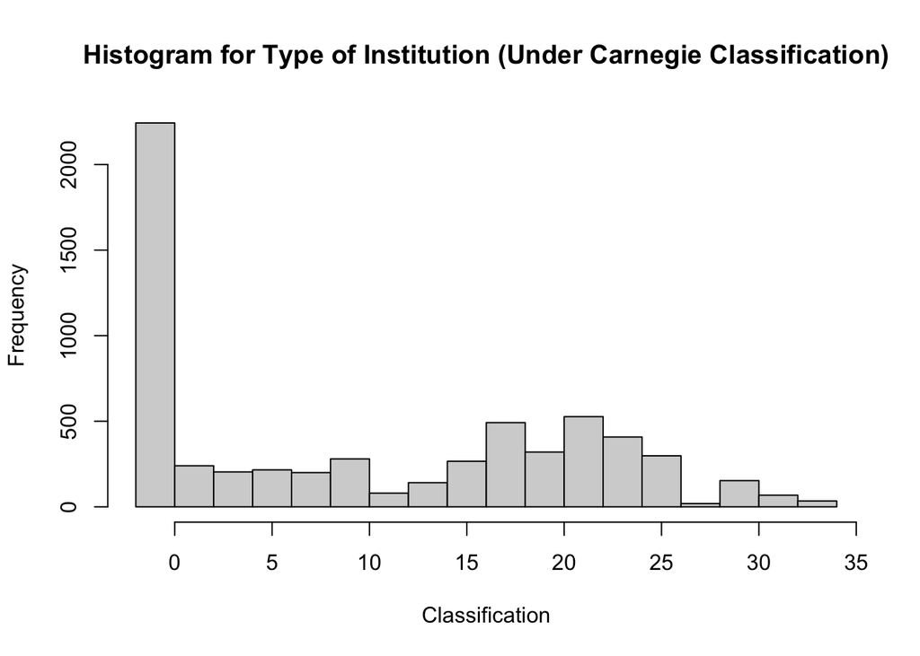

```r
hist(sapply(collegedata["CCBASIC"],as.numeric),xlab = "Classification",main = "Histogram for Type of Institution (Under Carnegie Classification)")
```

**To get a sense of what kind of institutions have missing values, I summarized the acceptance rates of institutions for which the basic Carnegie classification does not apply. I found that the acceptance rates are higher, with the difference the highest in the 75th percentile.**

```r
basiccarnegiemissing = collegedata %>% filter(CCBASIC == "-2")
admrates2 = sapply(basiccarnegiemissing["ADM_RATE"],as.numeric)
admrates2<-admrates2[!is.na(admrates)]
#admrates
skim(admrates2) %>% tibble() %>% kable()
```

| skim_type | skim_variable | n_missing | complete_rate | numeric.mean | numeric.sd | numeric.p0 | numeric.p25 | numeric.p50 | numeric.p75 | numeric.p100 | numeric.hist |
| --- | --- | --- | --- | --- | --- | --- | --- | --- | --- | --- | --- |
| numeric | data | 2065 | 0.079358 | 0.7244191 | 0.2594555 | 0 | 0.5148 | 0.7979 | 0.955875 | 1 | ▁▂▃▃▇ |

```r
print(length(admrates2))
```

```
## [1] 2243
```

## Comments

It looks like a lot of institutions are much different from what we’re familiar with. This isn’t too surprising. We need to consider that different kinds of relationships might exist within different kinds of institutions. For elite institutions, the relationship between acceptance rate and endowment might be different from the others. We also can seek to clearly characterize the differences between the ``elite’’ institutions and the others. In doing this, we need to make sure that systematic missing values do not skew our analysis—we can’t just remove missing values, because that might create a systematic bias.